# cyung25_FinalHomeworkCode_02

Charles Yung

2025-02-10

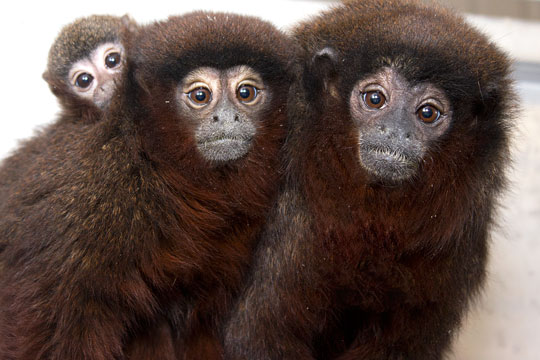

```r
knitr::include_graphics("CNPRCtitimonkeys©K.West-CNPRC003.jpg")
```

```r
# Created within the r chunk. Saved the monkey image into the same R project folder as the markdown document.
```

## Every Saturday morning, at the same time, a primatologist goes and sits in the forest to listen for titi monkey calls, counting the number of calls they hear in a 2 hour window from 5am to 7am. Based on previous knowledge, she believes that the mean number of calls she will hear in that time is exactly 15. Let X represent the appropriate Poisson random variable of the number of calls heard in each monitoring session.

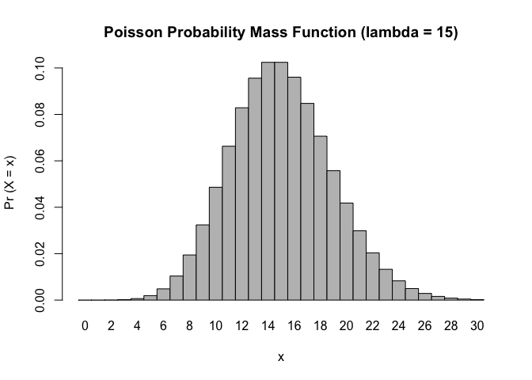

```r
lambda <- 15
# Probablity of more than 8 calls (x >8)
p_more_than_8 <- ppois(8, lambda= 15, lower.tail = FALSE)
# No calls x=0
p_0_calls <- dpois(0, lambda = 15)
# Probablity of 3 calls
p_3_calls <- dpois(3, lambda = 15)
# Plot mass function Poisson over values 0-30. But first lets set x value range and establish that we are using Poisson distribution. After that we will plot our barplot function.
x <- 0:30
poisson_probset <- dpois(x, lambda = 15)
barplot(poisson_probset, names.arg = x, space = 0, xlab = "x", ylab = "Pr (X = x)", main = "Poisson Probability Mass Function (lambda = 15)")
```

## Simulate 104 results (2 years of Saturday monitoring sessions)

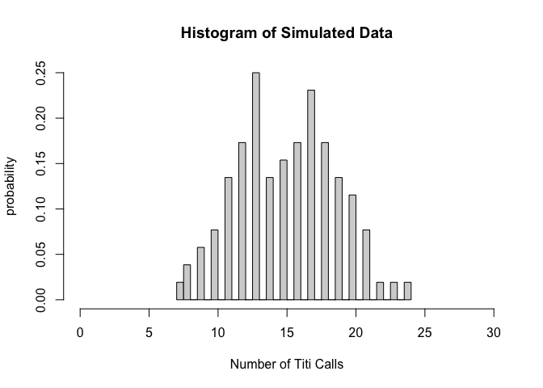

```r
set.seed (1) #sets up population
x <- 104
simu <- rpois (x, lambda = 15)
#account for 104 random trials, using rpois command. putting this entire equation as a simulation ensures less syntax errors. We keep lambda the same here. I set my variable as simu to prevent syntax errors
hist (simu, breaks = 30, xlim = c(0,30), probability = TRUE, main = "Histogram of Simulated Data", xlab = "Number of Titi Calls", ylab = "probability") #histogram accounts for all random trials, limits of x are also set. Coming back around to edit the code I added axis titles to make the graph look nicer
```

## The histogram generally is the same shape as the above poisson probability mass function. This makes sense because the histogram I just plotted is potentially the same probability of monkey calls, just at a broader timeframe.

## 5 Challenges

## Challenge 1: When I was making my git repo I straight up lost my original R markdown file somewhere in the computer so I ended up having to resort to manually uploading my files to the repository. I’m currently figuring out how to troubleshoot this. Edit 2/10 I wasn’t able to figure it out, but my peer was still able to review my stuff so at the very least that turned out okay.

## Challenge 2: I at first tried to load the monkey image as a web URL but after multiple attempts that didn’t work so I resorted to using the knit function instead since that’s a lot more closer to what we’re used to. The trick was to make sure I knew the name of the image file which was a lot more direct.

## Challenge 3: When coding for the simulation of 104 occurences it took me a while to get the commands to work until I put the random occurrences as one variable. I kept getting syntax errors beforehand and this was the simplest solution.

## Challenge 4: I still wasn’t able to completely understand the feature of the “breaks” command and I didn’t really know what exactly to set my value to. I think it has something to do with the graph scaling though, but I’ll figure it out.

## Challenge 5: I am currently trying to push my final homework file back to github and it’s still taking forever! I am going to try one more to to push it following Module 3 but if that doesn’t work… I’ll add it manually and come to office hours later.